# 2_Bagging_RF

2023-02-03

## Bagging

### Tunning de bagging

En este apartado se probaran algunas técnicas para realizar tunning de bagging, partiendo de un modelo “básico” utilizando las variables previamente seleccionadas con stepwise y al final de este apartado realizando pruebas de tunning sobre el tamaño muestral del dataset dengue.

Primer modelo de bagging con variables previamente seleccionadas

```r
rfgrid <- expand.grid(mtry = c(6))
set.seed(12345)
control_bagging <- trainControl(
    method = "cv",
    number = 4,
    savePredictions = "all",
    classProbs = TRUE)

bagging <- train(
    data = dengue,
    factor(varObjBin) ~ h10pix + temp90 + trees + trees90 + Ymin + Ymax + temp +
    humid + humid90,
    method = "rf",
    trControl = control_bagging,
    tuneGrid = rfgrid,
    linout = FALSE,
    ntree=5000,
    sampsize = 200,
    nodesize = 10,
    replace = TRUE)

bagging$modelType
```

[output not shown]

A continuación se explora el Out of bag error para este modelo, buscando parámetros para optimizacion, tal como lo indican los apuntes, se debe utilizar la función de randonForest() para extraer los datos y presentar gráfico:

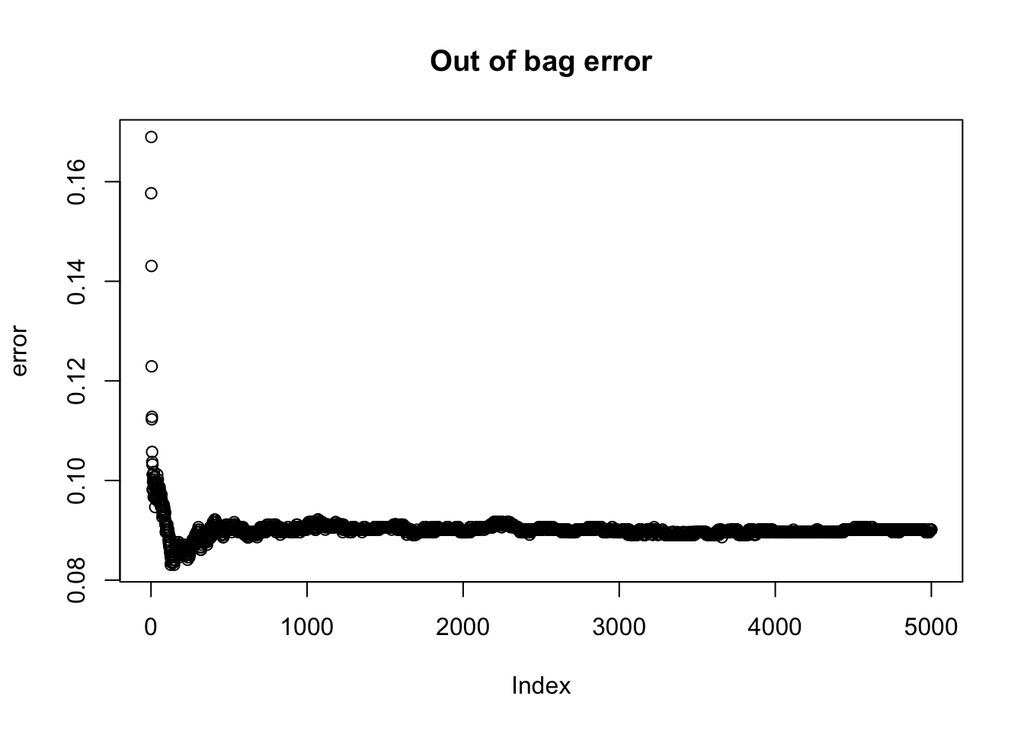

```r
# Plotear
baggingbis <- randomForest(
    factor(varObjBin) ~ h10pix + temp90 + trees + trees90 + Ymin + Ymax + temp +
    humid + humid90,
    data = dengue,
    mtry = 6,
    ntree = 5000,
    sampsize = 300,
    nodesize = 10,
    replace = TRUE)

#Se plotea la columna 1 que es OOB
plot(baggingbis$err.rate[, 1], main = "Out of bag error", ylab = "error")



# 1.3 Validacion cruzada rep bagging ------------------------------------------
```

A partir de las 1000 muestras se estabiliza el error de los datos analizados

### Validacion cruzada repetida para bagging

Se realizan algunas pruebas con validación cruzada repetida utilizando la función cruzadarfbin() y cuidando de incluir el parámetro mtry

```r
# Con validacion cruzada y 4 grupos
medias6 <-cruzadarfbin(
    data = dengue,
    vardep = "varObjBin",
    listconti = c("h10pix", "temp90", "trees", "trees90", "Ymin", "Ymax",
    "temp", "humid", "humid90"),
    listclass = c(""),
    grupos = 4,
    sinicio = 1234,
    repe = 5,
    mtry = 6,
    ntree =1000,
    replace = TRUE)

medias6$modelo <- "bagging"
```

```r
#  Anexo Manipulando tamanio muestral con 10 grupos no incluir en la seleccion
#  de modelos pues el grupos = es diferente
medias7 <-cruzadarfbin(
    data = dengue,
    vardep = "varObjBin",
    listconti = c("h10pix", "temp90", "trees", "trees90", "Ymin", "Ymax",
    "temp", "humid", "humid90"),
    listclass = c(""),
    grupos = 10,
    sinicio = 1234,
    repe=20,
    nodesize = 10,
    mtry = 6,
    ntree = 3000,
    replace = TRUE)

medias7$modelo <- "bagging_base"

# Bagging manipulando sampsize 1000
medias8 <-cruzadarfbin(
    data = dengue,
    vardep = "varObjBin",
    listconti = c("h10pix", "temp90", "trees", "trees90", "Ymin", "Ymax",
    "temp", "humid", "humid90"),
    listclass = c(""),
    grupos = 10,
    sinicio = 1234,
    repe=20,
    nodesize = 10,
    mtry = 6,
    ntree = 3000,
    replace = TRUE,
    sampsize = 1000 )

medias8$modelo <- "bagging1000"

# Bagging manipulando sampsize 1250
medias9 <-cruzadarfbin(
    data = dengue,
    vardep = "varObjBin",
    listconti = c("h10pix", "temp90", "trees", "trees90", "Ymin", "Ymax",
    "temp", "humid", "humid90"),
    listclass = c(""),
    grupos = 10,
    sinicio = 1234,
    repe=20,
    nodesize = 10,
    mtry = 6,
    ntree = 3000,
    replace = TRUE,
    sampsize = 1250 )

medias9$modelo <- "bagging1250"

# Bagging manipulando sampsize 1500
medias10 <-cruzadarfbin(
    data = dengue,
    vardep = "varObjBin",
    listconti = c("h10pix", "temp90", "trees", "trees90", "Ymin", "Ymax",
    "temp", "humid", "humid90"),
    listclass = c(""),
    grupos = 10,
    sinicio = 1234,
    repe=20,
    nodesize = 10,
    mtry = 6,
    ntree = 3000,
    replace = TRUE,
    sampsize = 1500 )

medias10$modelo <- "bagging1500"
```

Como parte de este complemento se evalúan las medias con la función genera_gráficos() para comparar cual de todos estos tamaños muestrales entrega mejores métricas:

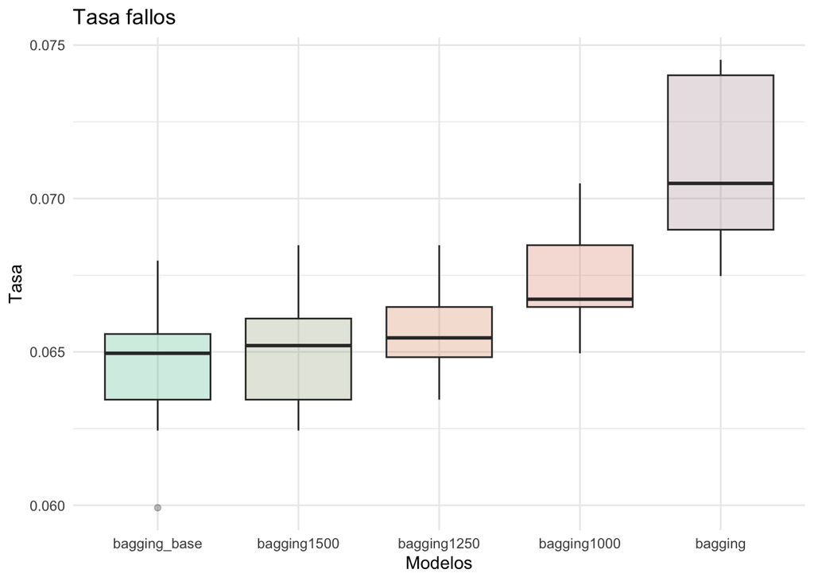

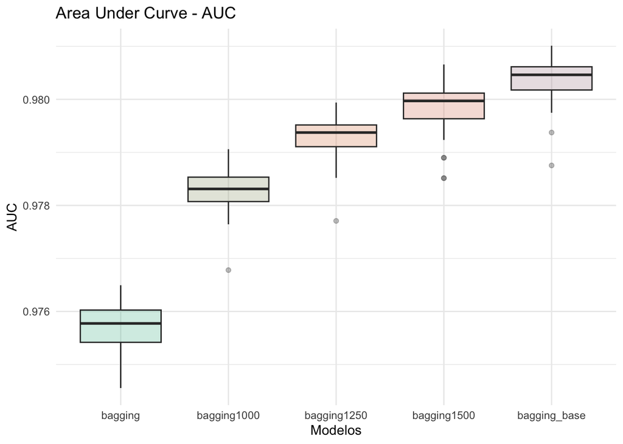

```r
# genera graficos para comparar tamanio muestral de bagging
genera_graficos(medias6, medias7, medias8, medias9, medias10, medias10)
```

**Observaciones**

- De todo el grupo y descartando bagging_base que no se considera, los mejores resultados están entre bagging 1250 y bagging1500. Para comparar modelos en el apartado final incluyendo los modelos de random forest se deja el modelo medias9.

## Random Forest Classifier

### Tunning de random forest

Primer modelo utilizando todas las variables y buscando las variables predictoras mas relevantes.

Nota: Solo como complemento a la practica, para observar como se comporta el algoritmo al seleccionar variables. Para comparar medias, validación cruzada y probar con diferentes números de arboles se utilizan las variables seleccionadas con *stepwise*

```r
# 2. Tuneo random forest -----------------------------------------------------
set.seed(12345)
rfgrid_rf <- expand.grid(mtry = c(3, 4, 5, 6, 7, 8, 9, 10, 11))

control_rf <- trainControl(
    method = "cv",
    number = 4,
    savePredictions = "all",
    classProbs = TRUE)

random_forest <- train(
    factor(varObjBin) ~.,
    data = dengue,
    method = "rf",
    trControl = control_rf,
    tuneGrid = rfgrid_rf,
    linout = FALSE,
    ntree =300,
    nodesize = 10,
    replace = TRUE,
    importance = TRUE)

# Mejor valor de mtry
random_forest$bestTune$mtry
```

Se obtienen los resultados de este primer modelo de randomforest

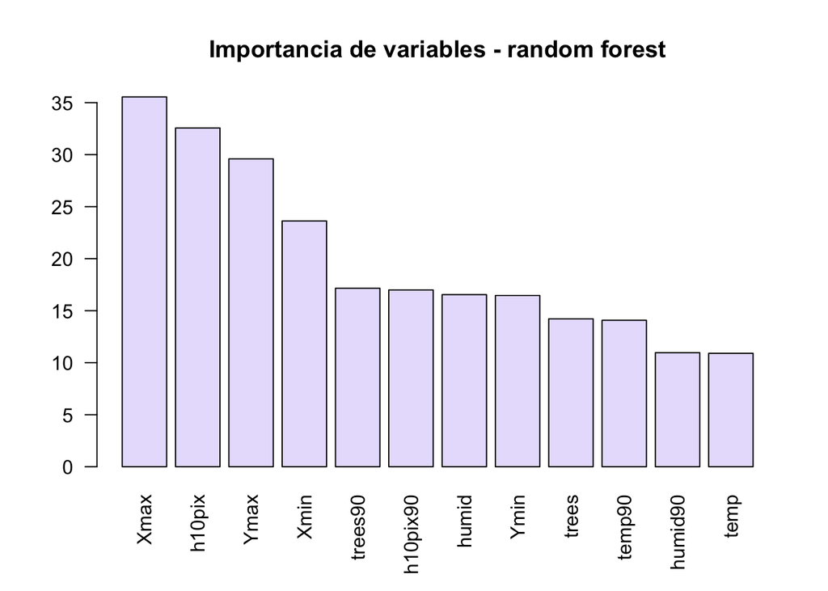

A continuación se prueba generando un bucle for() para buscar los mejores indicadores evaluando según el mtry y numero de trees, desde 300 a 2500 para observar su comportamiento y buscar los mejores parámetros para la validación cruzada:

```r
# random forest solo usando las variables mas relevantes
rfgrid_rf2 <- expand.grid(mtry = c(3, 4, 5, 6))
modellist <- list()
#train with different ntree parameters
for (ntree in c(300,500,1000,1500,2000,2500)){
    set.seed(12345)
    fit <- train(
        factor(varObjBin) ~ h10pix + temp90 + trees + trees90 + Ymin + Ymax +
        temp + humid + humid90,
        data = dengue,
        method = "rf",
        trControl = control_rf,
        tuneGrid = rfgrid_rf2,
        lineout = FALSE,
        ntree = ntree,
        nodesize = 10,
        replace = TRUE,
        importance = TRUE)
    key <- toString(ntree)
    modellist[[key]] <- fit
}

results <- resamples(modellist)
dotplot(results)
```

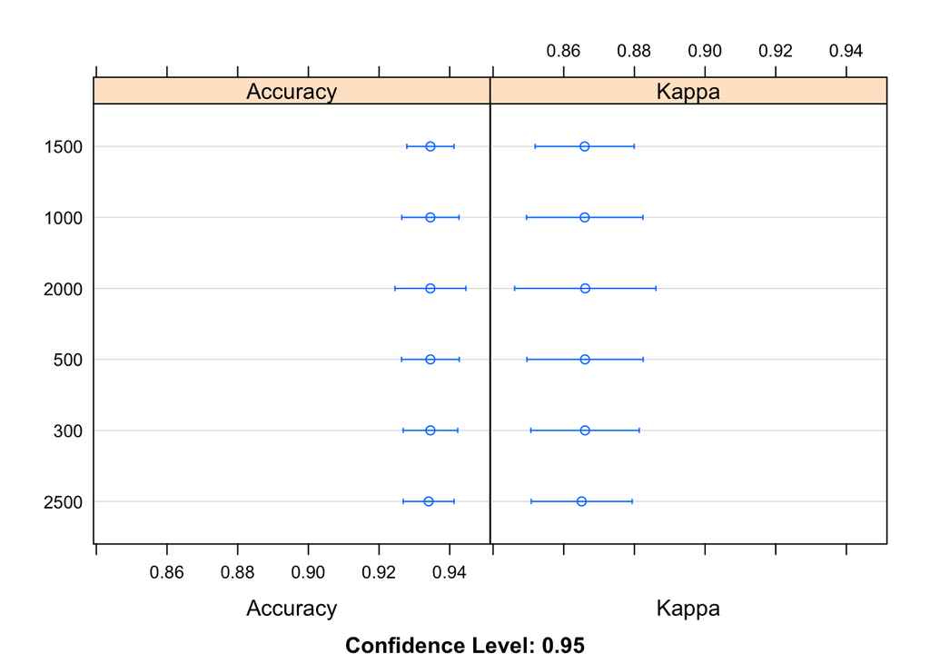

```r
dotplot(results)
```

```r
fit$bestTune
```

```
##   mtry
## 2    4
```

El gráfico dotplot() muestra el accuracy correspondiente a los trees evaluados en el ciclo for anterior, con esto los resultados en accuracy son similares pero por complejidad se prefiere dejar para pruebas en 500 trees. Para el parámetro *bestTune* el mtry es de 4 que también se dejara fijado en la validación cruzada.

### Validacion cruzada para random forest

Se genera la validación cruzada para random forest utilizando la función cruzadarfbin y los parámetros obtenidos del estudio anterior, con mtry= 4 y ntree = 500

```r
# Probar a dejar el parametro sampsize sin valor para que lo haga x defecto
medias11 <- cruzadarfbin(data = dengue, vardep = "varObjBin",
    listconti = c("h10pix", "temp90", "trees", "trees90", "Ymin", "Ymax",
    "temp", "humid", "humid90"),
    listclass = c(""),
    grupos = 4,
    sinicio = 1234,
    repe = 10,
    nodesize = 10,
    mtry = 4, ntree = 500, replace = TRUE)

medias11$modelo <- "randomforest"
```

### Comparacion de medias y boxplot

Utilizando la función genera_gráficos() se generan los gráficos para realizar comparación de medias y evaluar los modelos

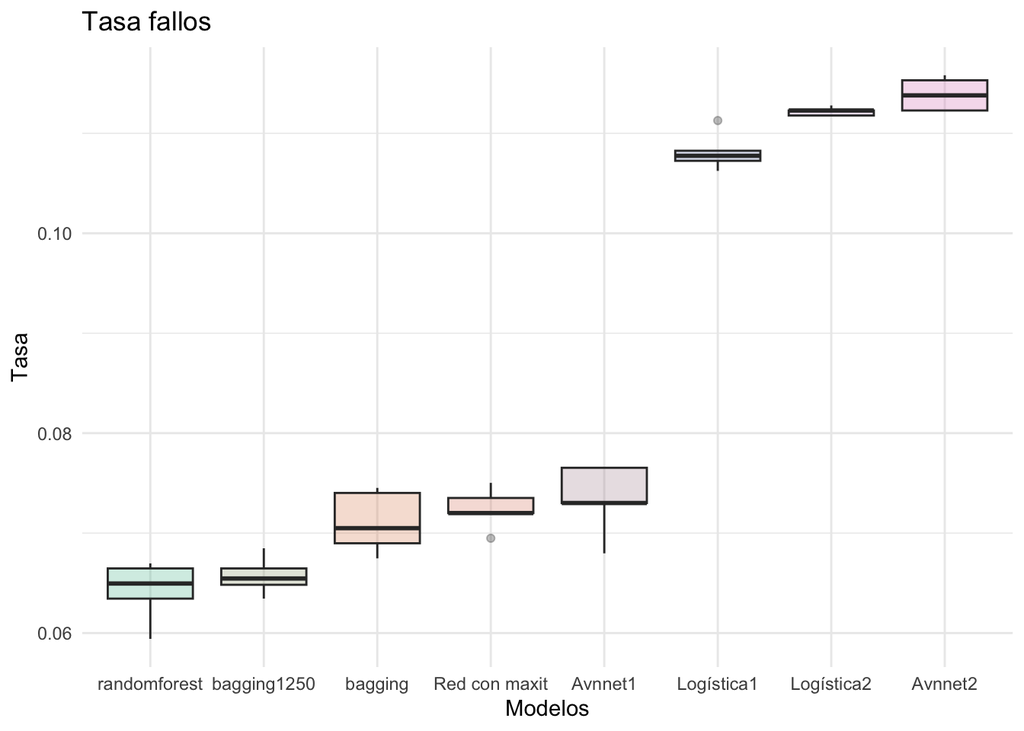

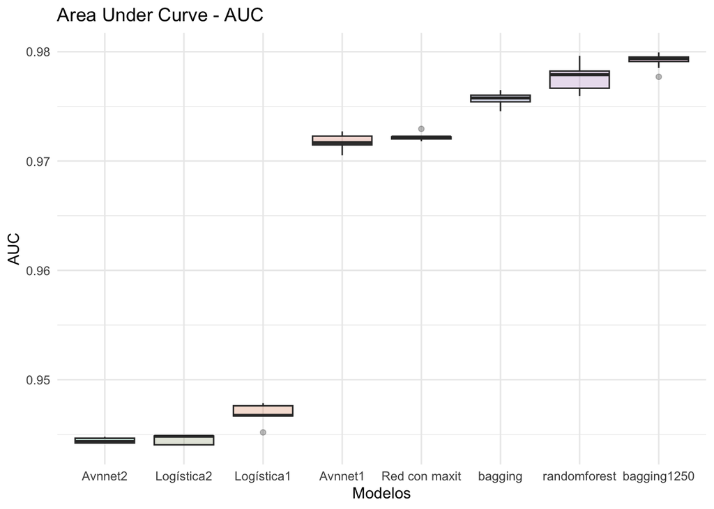

```r
genera_graficos(medias1, medias2, medias3, medias4, medias5,medias6, medias9,medias11)
```

Observaciones:

- De los algoritmos evaluados hasta el momento, randomforest (que muestra mas varianza comparado con los otros algoritmos) y bagging son los que muestran mejor rendimiento en AUC y tasa de fallos, dejando atrás las regresiones logísticas y las redes neuronales.